# Advancing Child Health: A Global Imperative

Produced for Data Analytics and Storytelling (DCU)

Author

Yugraj Vats

Published

April 12, 2025

# Introduction

Welcome to an in-depth exploration of a critical global issue: child health. In this analysis, we examine the complex factors affecting child health across different regions and time periods. Through data visualization and comprehensive analysis, we aim to highlight the challenges faced by millions of children worldwide, including issues related to malnutrition, disease, and limited access to healthcare. Join us as we uncover the underlying patterns, trends, and narratives behind this pressing issue and work towards a deeper understanding and meaningful solutions.

[interactive chart not shown]

**BCG vaccination rates vary significantly worldwide. In India, Brazil, and Russia, coverage exceeds 90%, reflecting strong health policies and higher tuberculosis (TB) prevalence. Conversely, in the United States, United Kingdom, and Australia, rates are below 20%, influenced by lower TB incidence and differing health strategies.**

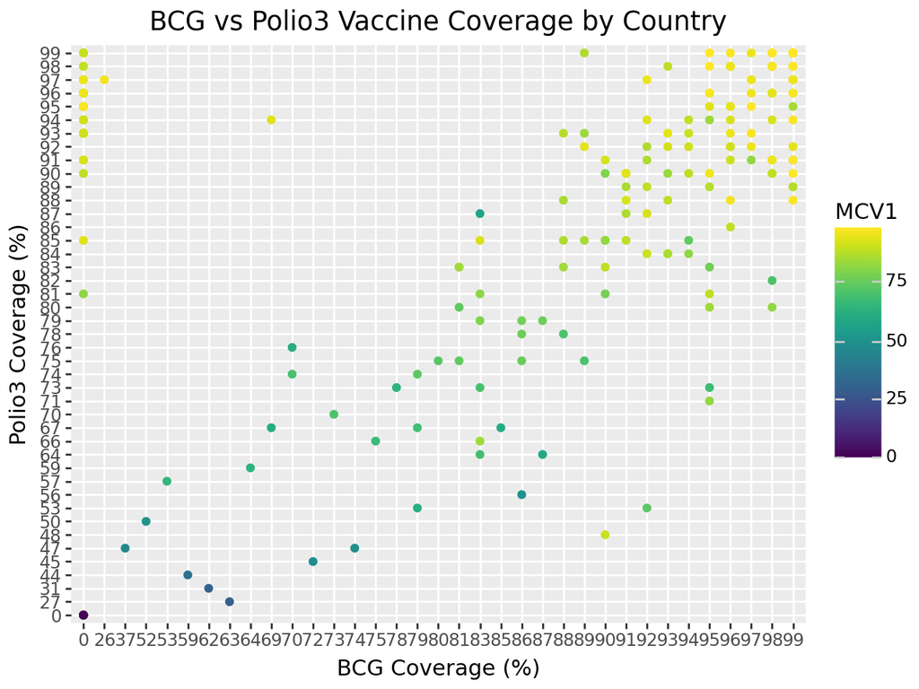

[interactive chart not shown]

**In a global snapshot of health intervention coverage, we see a varied landscape. HepB3 and Hib3 show strong, widespread adoption across many nations. Rota coverage, while present, appears less consistently high. PCV3 exhibits a more scattered pattern, with some regions achieving notable success while others lag. This visual narrative underscores the diverse progress in ensuring access to critical health interventions worldwide.**

[interactive chart not shown]

*Health intervention coverage varies globally*.* HepB3 shows the highest consistency across regions, especially in Western Europe and North America. Rota and PCV3 lag, particularly in less developed areas. Despite global efforts, significant disparities persist, emphasizing the need for improved vaccine accessibility and healthcare infrastructure in underrepresented regions*.

# Conclusion

Our exploration into child health has illuminated the profound impact of early-life conditions on lifelong well-being. From the foundational stages of prenatal development to the challenges faced during childhood, numerous factors—such as nutrition, access to healthcare, and environmental influences—play pivotal roles in shaping health outcomes. Addressing disparities in child health is not merely a matter of improving individual lives but also of fostering equitable societies and sustainable futures.

The journey ahead requires a collective commitment to ensuring that every child, regardless of background or circumstance, has the opportunity to thrive. By prioritizing child health, we invest in the well-being of future generations and lay the groundwork for a healthier, more just world.